# TDI Presentation

Saman Armal

May 22, 2019

### How does weather explain New York shooting rates?

**Objective**: For Data Incubator Project, I apply **Bayesian Multilevel** to model the rates of shooting in **the City of Greater New York**. While the second level of the model pools information across space (based on census data, **the social and economic background**), the first level simulate the trend and variability in response to the daily weather. This arrangement allows us to explore the variability of response with regard to the different social/economic background. If time permits, at the later stages of this investigation, I incorporate the effect of air quality (using AQI) to inform the rates of gun violence.

**Data**: For this analysis, I use multiple sources of information. This includes *NYPD shooting rate dataset (2006-2018)*, *NCDC daily weather data*, *NYC census data (American Community Survey - ACS DP03 and DP05 tables)*. Later, I will include the *AQI (Air Quality Index)* to study the relevancy of air pollution to the occurrence of shooting. The time-span of observation considered in this analysis is 2006-2018.

#### Preliminary Analysis: Temporal Varaiblity

A sample of NYDP shooting dataset looks like the following:

```r
print(head(sample_of_data,4))
```

```
##     Borough Precinct Murder Age Group Sex      Lat       Lon      Dates
## 7     BRONX       41  FALSE               40.81410 -73.90203 2016-09-09
## 56 BROOKLYN       75  FALSE   UNKNOWN   U 40.67111 -73.88143 2007-09-09
## 44   QUEENS      101  FALSE   UNKNOWN   U 40.60327 -73.75310 2009-09-09
## 96 BROOKLYN       67   TRUE     25-44   M 40.66252 -73.92701 2012-09-08
```

During recent years, the New York shooting rates constantly decreased. This negative trends in year-to-year data can root from diffrent sources (such as increase in the number of police stations, education and etc.)

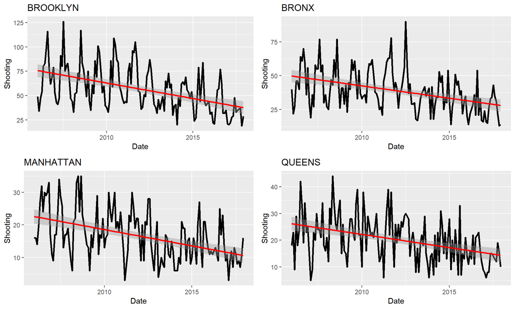

```r
grid.arrange(p1, p2, p3, p4, ncol = 2)
```

However, the shooting rates present a seasonal pattern, suggesting a correlation with weather variability. The Following figure shows that the number of incidents in the warmer months is higher than the shooting rates in colder seasons.

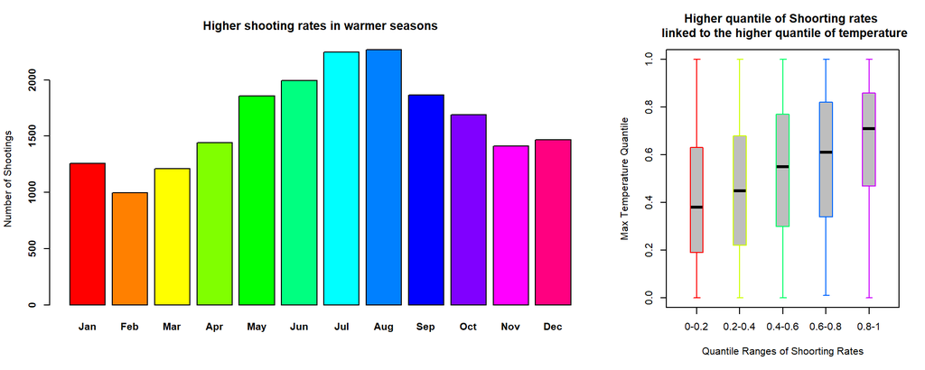

```r
df_plot <- aggregate(STATISTICAL_MURDER_FLAG~MONTH,as.data.frame(df),length)

layout(matrix(c(1,1,2), 1, 3, byrow = TRUE))

barplot(sapply(1:12,function(x) length(df$STATISTICAL_MURDER_FLAG[which(df$MONTH==x)])),
        col=rainbow(12),names=month.abb[1:12],ylab='Number of Shootings',
        main = 'Higher shooting rates in warmer seasons',
        font=2,cex.axis = 1,cex.names=1,cex.lab=1)

boxplot(sapply(1:(length(thresh)-1), function(x) weather_shooting[3,which(classified_shootings==x)]),col='grey',
        staplecol=rainbow(5),whiskcol=rainbow(5),
        boxcol=rainbow(5),medcol='black',
        xlab='Quantile Ranges of Shoorting Rates',
        whisklty=1,ylab='Max Temperature Quantile',
        main = 'Higher quantile of Shoorting rates \n linked to the higher quantile of temperature',
        outline=FALSE,names=labels_ins,boxwex = 0.3,
        names.font=2,cex.axis = 1,cex.names=1,cex.lab=1)
```

#### Preliminary Analysis: Spatial Varaiblity

The spatial distribution of shooting incident yields useable information on how the affected areas changed over time. The following map demonstrates the location of gun violence in 2007.

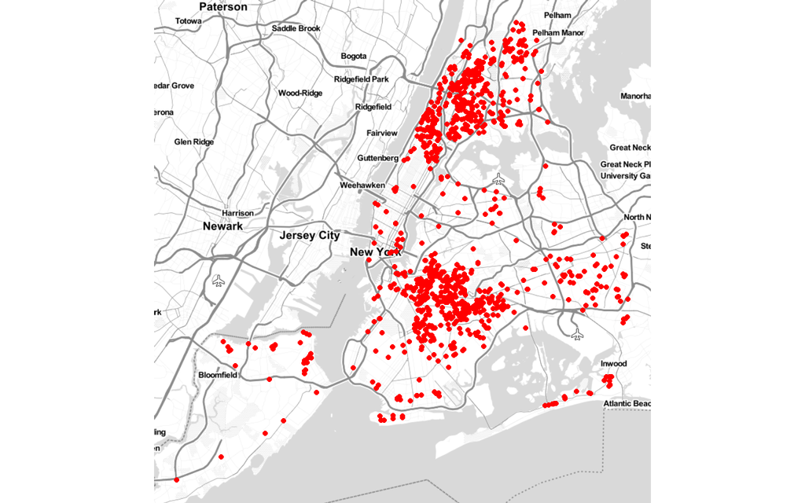

Using the Kernel estimators, I looked at the density of the number of incindents within 2-km radius. It is observed that the density of crimes decrease over time.

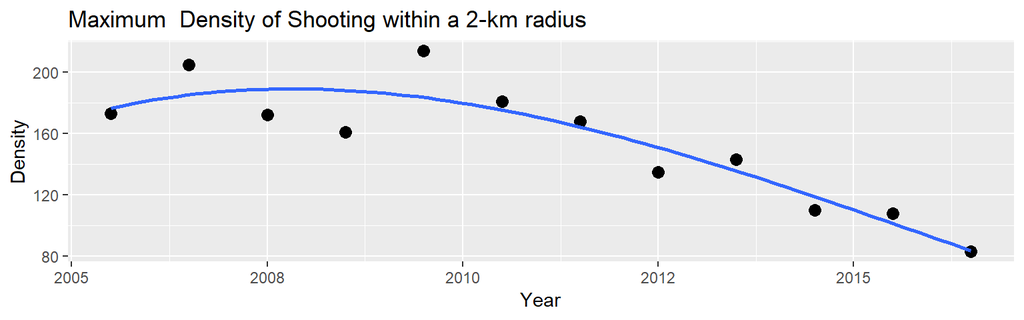

[figure not shown]

#### The Bayesian Hierarchical Model: Zero-Inflated Poisson Regression Method

The Socioeconomic status in five boroughs of the greater New York City diversifies, but the precincts inside each borough might be similar. Therefore, rather than aggregating data over each borough, the model benefits from the social/economic background to pool the shooting rates over precincts and capture their variability response to different predictors, including time and weather. In this analysis, we look at the **144 months of data for 76 precincts across New York City boroughs**. The model provides a mixtures of a Poisson and Bernoulli probability mass function to allow more flexibility in simulating the probability of zero outcomes.

The model implments on JAGS to apply Markov chain Monte Carlo (MCMC):

- First level infroms the shooting rates with time+weather varaibles
- Second level applies social/economic background including Poverty, Employment and Income.
- The last level infroms priors in the Bayesian model

```r
# This model runs on JAGS

model <- function() {

  for (m in 1:n_PRECINCT) #loop through all Police Precincts
  {
    for(i in 1:ntimes){ #loop through all data points
      y[i,m] ~ dpois(mu[i,m])
      mu[i,m] <- lambda[i,m]*z[i,m] + 0.0001 ## hack required for Rjags -- otherwise 'incompatible'-error
      z[i,m] ~ dbern(psi[m])
      log(lambda[i,m]) <- alpha[m] + beta_time[m]*time[i] + beta_prcp[m]*PRCP[i] + beta_tmax[m]*TMAX[i]

      # alpha is overall intercept and betas are liner effect
    }
  }

  # priors:

  for (m in 1:n_PRECINCT)
  {

    alpha[m] ~ dnorm(a_alpha[m]+b_alpha[m]*Poverty[m]+c_alpha[m]*Unemployment[m]+d_alpha[m]*IncomePerCap[m]+e_alpha[m]*Citizen[m],0.01)

    a_alpha[m] ~ dnorm(0, 0.01)
    b_alpha[m] ~ dnorm(0, 0.01)
    c_alpha[m] ~ dnorm(0, 0.01)
    d_alpha[m] ~ dnorm(0, 0.01)
    e_alpha[m] ~ dnorm(0, 0.01)

    beta_time[m] ~ dnorm(a_beta1[m]+b_beta1[m]*Poverty[m]+c_beta1[m]*Unemployment[m]+d_beta1[m]*IncomePerCap[m]+e_beta1[m]*Citizen[m],0.01)
    beta_prcp[m] ~ dnorm(a_beta2[m]+b_beta2[m]*Poverty[m]+c_beta2[m]*Unemployment[m]+d_beta2[m]*IncomePerCap[m]+e_beta2[m]*Citizen[m],0.01)
    beta_tmax[m] ~ dnorm(a_beta3[m]+b_beta3[m]*Poverty[m]+c_beta3[m]*Unemployment[m]+d_beta3[m]*IncomePerCap[m]+e_beta3[m]*Citizen[m],0.01)

    a_beta1[m] ~ dnorm(0, 0.01)
    b_beta1[m] ~ dnorm(0, 0.01)
    c_beta1[m] ~ dnorm(0, 0.01)
    d_beta1[m] ~ dnorm(0, 0.01)
    e_beta1[m] ~ dnorm(0, 0.01)

    a_beta2[m] ~ dnorm(0, 0.01)
    b_beta2[m] ~ dnorm(0, 0.01)
    c_beta2[m] ~ dnorm(0, 0.01)
    d_beta2[m] ~ dnorm(0, 0.01)
    e_beta2[m] ~ dnorm(0, 0.01)

    a_beta3[m] ~ dnorm(0, 0.01)
    b_beta3[m] ~ dnorm(0, 0.01)
    c_beta3[m] ~ dnorm(0, 0.01)
    d_beta3[m] ~ dnorm(0, 0.01)
    e_beta3[m] ~ dnorm(0, 0.01)

    psi[m] ~ dunif(0, 1) # proportion of non-zeros

  }
}
```

##### The preliminary results on Bayesian Hierarchical Model

The following Figures represent The outcome of the model on two different Police Precincts. The simulated curve shows the median of 3000 iterations:

The First Case: With lots of zero points

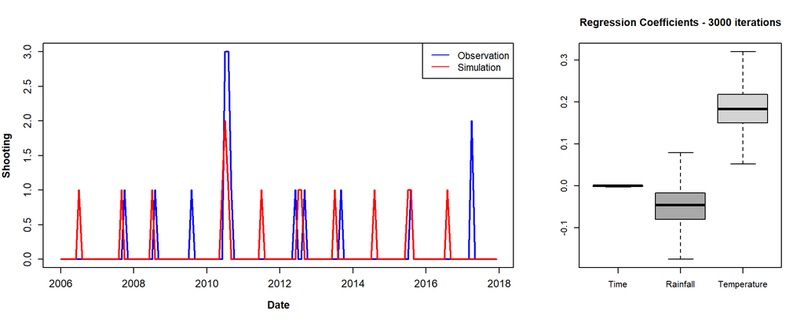

The Second Case: With few zero points

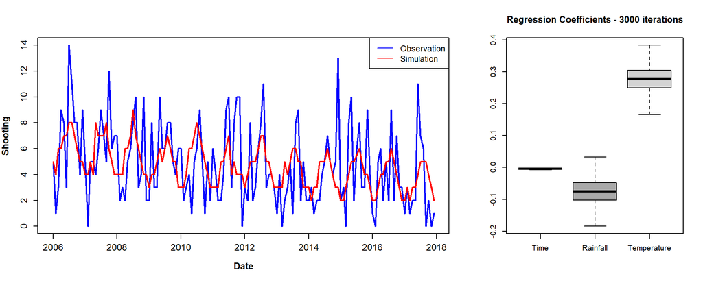

### Future Work

- Improving the model performance by adjusting the priors, and selecting the best set of predictors, applying the Watanabe-Akaike Information Criterion (WAIC)
- Evaluating the potential of weather variables and air pollution to predict the variability of shootings
- Understanding the changes in the social/economic background and their link to time-space variability of shooting across different precincts of greater New York City

…